# Trabajo final

Indicaciones:

# Parte 2

Contaran con toda la información sobre el trabajo en la carpeta "Trabajo Final" del Github de curso. Lean con cuidado las indicaciones. Algunos puntos a tener en cuenta:

Puedes elegir una de estas dos opciones

- Indicadores de Desarrollo GlobaL, a nivel país.
- El IDH, a nivel distrital, provincial o departamental.

Realiza 4 gráficos con la base de datos de tu elección. Ojo que cualquiera de las opciones implica realizar alguna limpieza de los datos.

Aquí van algunas ideas:

Para los indicadores de desarrollo global:

- puedes ver la evolución en el tiempo de un sólo indicador, para un sólo pais, o región.
- Puedes hacer la comparación entre la evolucion de varios países.
- puedes ver la comparación entre países de un sólo indicador. Puedes enfocarte en una o varias regiones.
- puedes ver la relación de dos o más indicadores.

Para el IDH:

- puedes ver la comparación de alguno de los indicadores entre distritos dentro de un departamento.
- puedes ver la relación de dos indicadores que componen el IDH, entre ellos.

Hay más opciones de temas para los indicadores de desarrollo global.

Formato de entrega: Un archivo txt con la URL de la web en Github o notebook del trabajo que también incluya la URL de la web en github. Tener en consideración que dado que el trabajo es de grupos de 5 solo sera necesario que este publicado en un Github. Además dentro de la pagina de Github del trabajo final esta un tutorial de como publicar sus paginas en formato html.

```python
import pandas as pd
data  = pd.read_csv('Datasets/Data-1.csv')
```

[output not shown]

**Grafico 1**

```python
#----- grafico comparando access to electricity vs access to electricity rural, mostrando el gap a traves del tiempo en peru
# seleccionando data de peru
peru_df= data[(data['Country Name'] == 'Peru')]
peru_df = peru_df.reset_index(drop=True)

# seleccionando variables de interes
peru_electr = peru_df.iloc[[0,1]]
peru_electr = peru_electr.T

peru_electr = peru_electr.iloc[4:]
#columnas:
#Access to electricity (% of population)
#Access to electricity, rural (% of rural population

# lidiando con datos faltantes
import numpy as np
peru_electr.replace("..", np.nan, inplace=True)
peru_electr = peru_electr.dropna()
peru_electr.head(10)

#arreglando nombres de columnas
peru_electr.index = peru_electr.index.str.extract(r'(\d{4})')[0]
peru_electr_df = peru_electr.rename(columns = {peru_electr.columns[0]: 'total',
                                                peru_electr.columns[1]: 'rural'})

peru_electr_df['total'] = pd.to_numeric(peru_electr_df['total'])
peru_electr_df['rural'] = pd.to_numeric(peru_electr_df['rural'])

peru_electr_df.info()
```

[output not shown]

[output not shown]

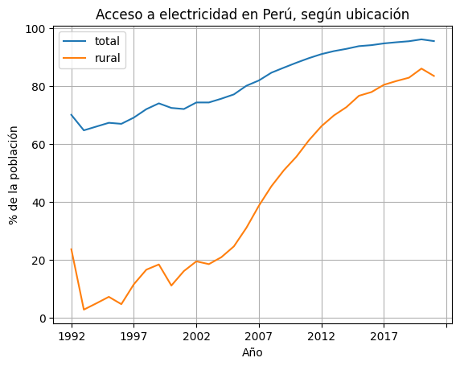

```python
import matplotlib.pyplot as plt

peru_electr_df.plot()
plt.title('Acceso a electricidad en Perú, según ubicación',fontdict={'fontsize':12})
plt.xlabel('Año')
plt.ylabel('% de la población')
plt.grid(True)
plt.show()
```